# 11082245_BIOL63101_Assignment1

11082245

2022-11-17

# Before Reading

The R script, R Markdown and this `.html` file were uploaded to [my GitHub repository](https://github.com/azanghai/UoM_BIOL63101_Assignment_1), where you can view or download my code.

**To get the best browsing experience, maximize the browser.**

**You can use the switch button on the left if you want to switch to a different colour theme.**

# Import Required Packages

```r
library(tidyverse)
library(dplyr)
library(ggridges)
library(skimr)
library(ggpubr)
library(descriptr)
```

The `skimr` and `descriptr` packages are used to calculate descriptive statistics. The `ggpubr` package is used to draw a bar chart with compared means. Other packages are from the class.

# Import Data

I use a built-in function to import `.csv` data and name it `raw_data`.

```r
# importing raw data
raw_data <- read.csv("assignment_1_data.csv")
```

# Convert Data into Long Format

The data needs to be converted into the long format for further analysis, which can be achieved in two ways.

## Using gather()

```r
converted_data <- gather(
  data = raw_data,
  key = "Conditions",
  value = "RT",
  2:5
)
```

## Using pivot_longer()

```r
converted_data <- raw_data %>%
  pivot_longer(
    cols = c(Condition1, Condition2, Condition3, Condition4),
    names_to = "Conditions",
    values_to = "RT"
  )
```

# Make some adjustments for the labels to be human-readable.

Conditions are renamed by their meaning, for example:

> `Condition1` was transferred to `ExpNum_Num`, which means Condition1 corresponds to Expectation of a Number, and a subsequent Number Target.

Also, for the needs of plotting. I have created two new columns to represent what Expectations and Targets are.

```r
# rewrite conditions
converted_data = converted_data %>%
  mutate(Conditions = factor(Conditions)) %>%
  mutate(
    Conditions = case_when(
      Conditions == "Condition1" ~ "ExpNum_Num",
      Conditions == "Condition2" ~ "ExpNum_Let",
      Conditions == "Condition3" ~ "ExpLet_Num",
      Conditions == "Condition4" ~ "ExpLet_Let"
    )
  ) %>%
  mutate(
    Expectation = case_when(
      Conditions == "ExpNum_Num" ~ "Number",
      Conditions == "ExpNum_Let" ~ "Number",
      Conditions == "ExpLet_Let" ~ "Letter",
      Conditions == "ExpLet_Num" ~ "Letter"
    )
  ) %>%
  mutate(
    Target = case_when(
      Conditions == "ExpNum_Num" ~ "Number",
      Conditions == "ExpNum_Let" ~ "Letter",
      Conditions == "ExpLet_Let" ~ "Letter",
      Conditions == "ExpLet_Num" ~ "Number"
    )
  ) %>%
  mutate(Expectation = factor(Expectation)) %>%
  mutate(Target = factor(Target))
```

I have also reordered the sequence of conditions to demonstrate plots in a better way.

```r
# reorder factor sequence
converted_data <- converted_data %>%
  mutate(Conditions = factor(Conditions,
                             levels = c("ExpNum_Num",
                                        "ExpNum_Let",
                                        "ExpLet_Let",
                                        "ExpLet_Num")))
```

# Summary Statistics for Each Condition

Summary statistics report was generated by using R packages. I found two different packages which suit this task.

## Using `skimr` package

The `skimr` package provides a simple way to look at descriptive statistics for the data. It provides Mean, SD, Quantile and mini histogram.

```r
# take a look about data summary.
converted_data %>%
  dplyr::group_by(Conditions) %>%
  skim() %>%
  dplyr::filter(skim_variable == "RT")
```

Data summary

| Name | Piped data |
| --- | --- |
| Number of rows | 192 |
| Number of columns | 5 |
| _______________________ |  |
| Column type frequency: |  |
| numeric | 1 |
| ________________________ |  |
| Group variables | Conditions |

**Variable type: numeric**

| skim_variable | Conditions | n_missing | complete_rate | mean | sd | p0 | p25 | p50 | p75 | p100 | hist |
| --- | --- | --- | --- | --- | --- | --- | --- | --- | --- | --- | --- |
| RT | ExpNum_Num | 0 | 1 | 995.42 | 26.51 | 928 | 982.25 | 995.5 | 1011.00 | 1067 | ▁▃▇▃▁ |
| RT | ExpNum_Let | 0 | 1 | 1245.73 | 29.80 | 1202 | 1225.25 | 1239.5 | 1262.00 | 1337 | ▇▇▅▂▁ |
| RT | ExpLet_Let | 0 | 1 | 995.85 | 29.66 | 899 | 978.75 | 997.5 | 1015.00 | 1056 | ▁▂▆▇▂ |
| RT | ExpLet_Num | 0 | 1 | 1251.73 | 27.99 | 1184 | 1236.00 | 1252.5 | 1271.25 | 1309 | ▂▃▇▇▂ |

## Using `descriptr` package

The `descriptr` package provides more descriptive statistics.

```r
# descriptr can also do this
converted_data %>%
  filter(Conditions == "ExpNum_Num") %>%
  ds_summary_stats()
```

```
## --------------------------------- Variable: ID ---------------------------------
##
##                         Univariate Analysis
##
##  N                       48.00      Variance               196.00
##  Missing                  0.00      Std Deviation           14.00
##  Mean                    24.50      Range                   47.00
##  Median                  24.50      Interquartile Range     23.50
##  Mode                     1.00      Uncorrected SS       38024.00
##  Trimmed Mean            24.50      Corrected SS          9212.00
##  Skewness                 0.00      Coeff Variation         57.14
##  Kurtosis                -1.20      Std Error Mean           2.02
##
##                               Quantiles
##
##               Quantile                            Value
##
##              Max                                  48.00
##              99%                                  47.53
##              95%                                  45.65
##              90%                                  43.30
##              Q3                                   36.25
##              Median                               24.50
##              Q1                                   12.75
##              10%                                   5.70
##              5%                                    3.35
##              1%                                    1.47
##              Min                                   1.00
##
##                             Extreme Values
##
##                 Low                                High
##
##   Obs                        Value       Obs                        Value
##    1                           1         48                          48
##    2                           2         47                          47
##    3                           3         46                          46
##    4                           4         45                          45
##    5                           5         44                          44
##
```

[output cut: 26 more lines]

```
##               10%                                     960.40
##               5%                                      956.05
##               1%                                      935.99
##               Min                                     928.00
##
##                                Extreme Values
##
##                   Low                                  High
##
##   Obs                           Value       Obs                           Value
##   24                             928        47                            1067
##   21                             945        40                            1048
##   36                             955        42                            1037
##    6                             958         8                            1036
##   32                             959        23                            1028
```

```r
converted_data %>%
  filter(Conditions == "ExpNum_Let") %>%
  ds_summary_stats()
```

```
## --------------------------------- Variable: ID ---------------------------------
##
##                         Univariate Analysis
##
##  N                       48.00      Variance               196.00
##  Missing                  0.00      Std Deviation           14.00
##  Mean                    24.50      Range                   47.00
##  Median                  24.50      Interquartile Range     23.50
##  Mode                     1.00      Uncorrected SS       38024.00
##  Trimmed Mean            24.50      Corrected SS          9212.00
##  Skewness                 0.00      Coeff Variation         57.14
##  Kurtosis                -1.20      Std Error Mean           2.02
##
##                               Quantiles
##
##               Quantile                            Value
##
##              Max                                  48.00
##              99%                                  47.53
##              95%                                  45.65
##              90%                                  43.30
##              Q3                                   36.25
##              Median                               24.50
##              Q1                                   12.75
##              10%                                   5.70
##              5%                                    3.35
##              1%                                    1.47
##              Min                                   1.00
##
##                             Extreme Values
##
##                 Low                                High
##
##   Obs                        Value       Obs                        Value
##    1                           1         48                          48
##    2                           2         47                          47
##    3                           3         46                          46
##    4                           4         45                          45
##    5                           5         44                          44
##
```

[output cut: 26 more lines]

```
##               10%                                     1213.20
##               5%                                      1207.05
##               1%                                      1202.47
##               Min                                     1202.00
##
##                                Extreme Values
##
##                   Low                                  High
##
##   Obs                           Value       Obs                           Value
##   10                            1202        31                            1337
##    9                            1203         3                            1310
##   24                            1206        17                            1298
##   33                            1209        18                            1292
##   35                            1209        22                            1292
```

```r
converted_data %>%
  filter(Conditions == "ExpLet_Num") %>%
  ds_summary_stats()
```

```
## --------------------------------- Variable: ID ---------------------------------
##
##                         Univariate Analysis
##
##  N                       48.00      Variance               196.00
##  Missing                  0.00      Std Deviation           14.00
##  Mean                    24.50      Range                   47.00
##  Median                  24.50      Interquartile Range     23.50
##  Mode                     1.00      Uncorrected SS       38024.00
##  Trimmed Mean            24.50      Corrected SS          9212.00
##  Skewness                 0.00      Coeff Variation         57.14
##  Kurtosis                -1.20      Std Error Mean           2.02
##
##                               Quantiles
##
##               Quantile                            Value
##
##              Max                                  48.00
##              99%                                  47.53
##              95%                                  45.65
##              90%                                  43.30
##              Q3                                   36.25
##              Median                               24.50
##              Q1                                   12.75
##              10%                                   5.70
##              5%                                    3.35
##              1%                                    1.47
##              Min                                   1.00
##
##                             Extreme Values
##
##                 Low                                High
##
##   Obs                        Value       Obs                        Value
##    1                           1         48                          48
##    2                           2         47                          47
##    3                           3         46                          46
##    4                           4         45                          45
##    5                           5         44                          44
##
```

[output cut: 26 more lines]

```
##               10%                                     1220.40
##               5%                                      1200.85
##               1%                                      1186.82
##               Min                                     1184.00
##
##                                Extreme Values
##
##                   Low                                  High
##
##   Obs                           Value       Obs                           Value
##   22                            1184        18                            1309
##   21                            1190        43                            1307
##   34                            1197        37                            1293
##   45                            1208        25                            1289
##    6                            1219        35                            1282
```

```r
converted_data %>%
  filter(Conditions == "ExpLet_Let") %>%
  ds_summary_stats()
```

```
## --------------------------------- Variable: ID ---------------------------------
##
##                         Univariate Analysis
##
##  N                       48.00      Variance               196.00
##  Missing                  0.00      Std Deviation           14.00
##  Mean                    24.50      Range                   47.00
##  Median                  24.50      Interquartile Range     23.50
##  Mode                     1.00      Uncorrected SS       38024.00
##  Trimmed Mean            24.50      Corrected SS          9212.00
##  Skewness                 0.00      Coeff Variation         57.14
##  Kurtosis                -1.20      Std Error Mean           2.02
##
##                               Quantiles
##
##               Quantile                            Value
##
##              Max                                  48.00
##              99%                                  47.53
##              95%                                  45.65
##              90%                                  43.30
##              Q3                                   36.25
##              Median                               24.50
##              Q1                                   12.75
##              10%                                   5.70
##              5%                                    3.35
##              1%                                    1.47
##              Min                                   1.00
##
##                             Extreme Values
##
##                 Low                                High
##
##   Obs                        Value       Obs                        Value
##    1                           1         48                          48
##    2                           2         47                          47
##    3                           3         46                          46
##    4                           4         45                          45
##    5                           5         44                          44
##
```

[output cut: 26 more lines]

```
##               10%                                     960.10
##               5%                                      949.50
##               1%                                      918.74
##               Min                                     899.00
##
##                                Extreme Values
##
##                   Low                                  High
##
##   Obs                           Value       Obs                           Value
##   46                             899        42                            1056
##   43                             941        10                            1047
##    6                             946        27                            1046
##   18                             956        36                            1034
##    9                             958        44                            1031
```

# Visualizations

## Visualizations for Each Condition

### General Overview

The density plot gives us a general overview about how data is distributed. he plot shows that the reaction time(RT) is different *when expectation and target are consistent* and *when they are not*. Meanwhile, it seems that the data in each condition is normally distributed.

#### Separated Density Plot

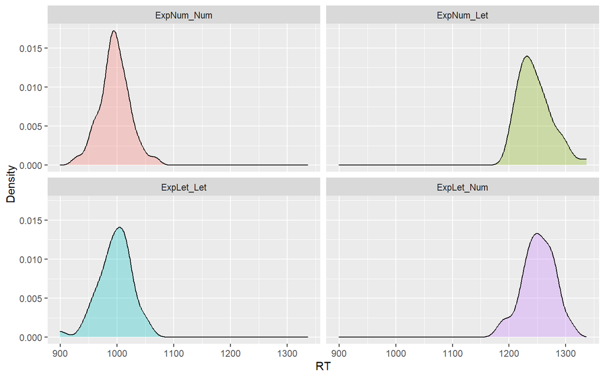

Density Plot Under Each Condition

```r
ggplot(data = converted_data, aes(x = RT)) +
  geom_density(aes(fill = Conditions), alpha = .3) +
  facet_wrap(~Conditions) +
  labs(y = "Density") +
  theme(legend.position = "none")
```

#### Density Ridges Plot

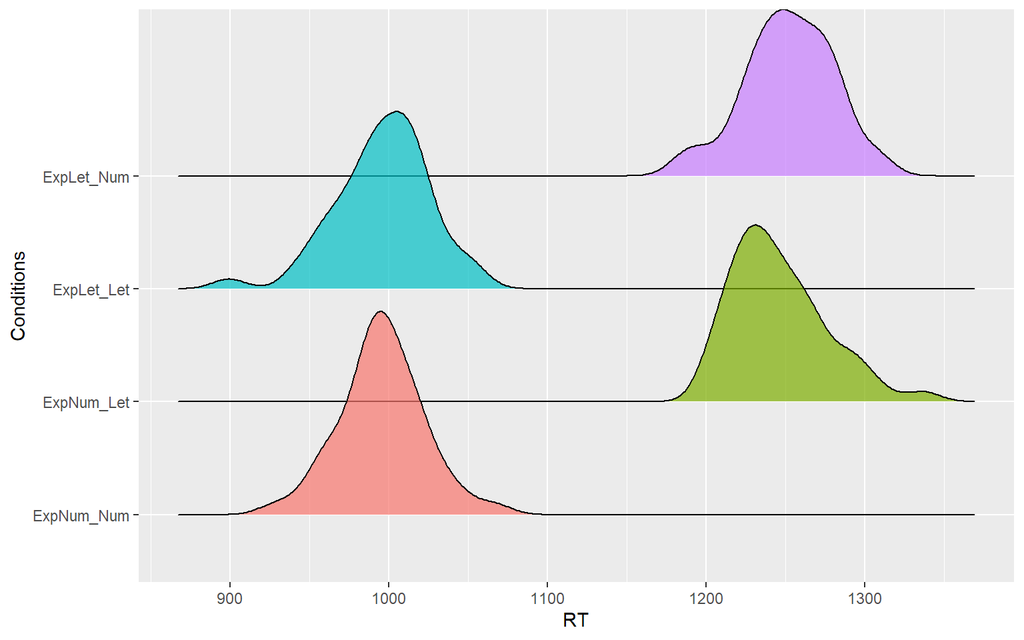

Density Ridges Plot

```r
ggplot(data = converted_data) +
  geom_density_ridges(mapping = aes(x = RT, y = Conditions, fill = Conditions),
                      alpha = .7) +
  theme(legend.position = "none")
```

## Discovery about distribution

And if we put the data in ascending order and in the same plot, we can find a huge difference between the two data groups.

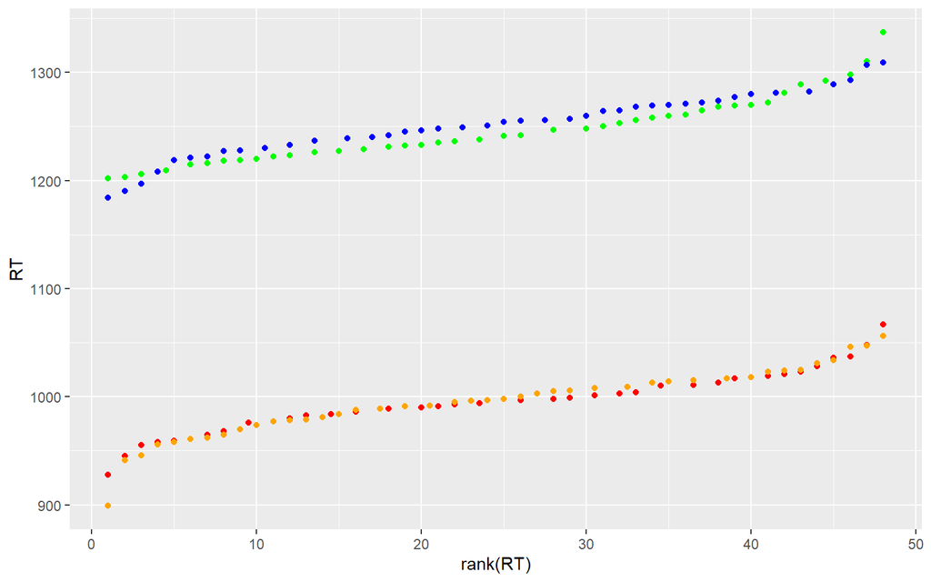

Scatter Plot for 4 Conditions

```r
ggplot(mapping = aes(
  x = rank(RT),
  y = RT
)) +
  geom_point(
    data = filter(converted_data, Conditions == "ExpNum_Num"),
    color = "red"
  ) +
  geom_point(
    data = filter(converted_data, Conditions == "ExpNum_Let"),
    color = "green"
  ) +
  geom_point(
    data = filter(converted_data, Conditions == "ExpLet_Let"),
    color = "orange"
  ) +
  geom_point(
    data = filter(converted_data, Conditions == "ExpLet_Num"),
    color = "blue"
  )
```

We can draw a Q-Q plot to find whether the data is distributed normally.

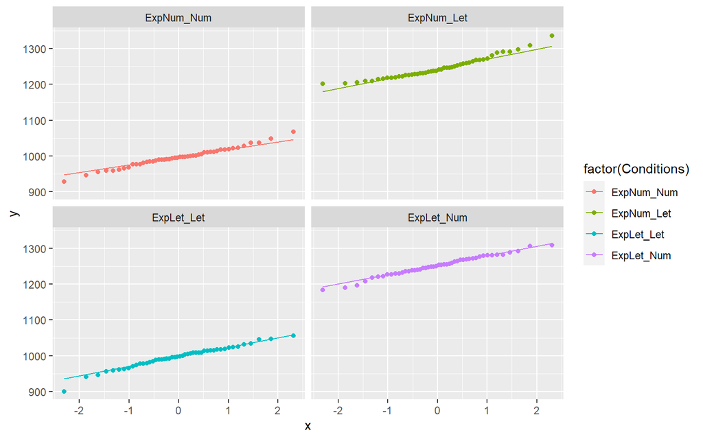

Q-Q plot for Each Condition

```r
# distribution check
ggplot(data = converted_data, aes(sample = RT, colour = factor(Conditions))) +
  geom_qq() +
  geom_qq_line() +
  facet_wrap(~Conditions)
```

The data seems perfect and normally distributed(by viewing the plot).

## Plot with More Information

We can also view the data in a different plot which may provide more information.

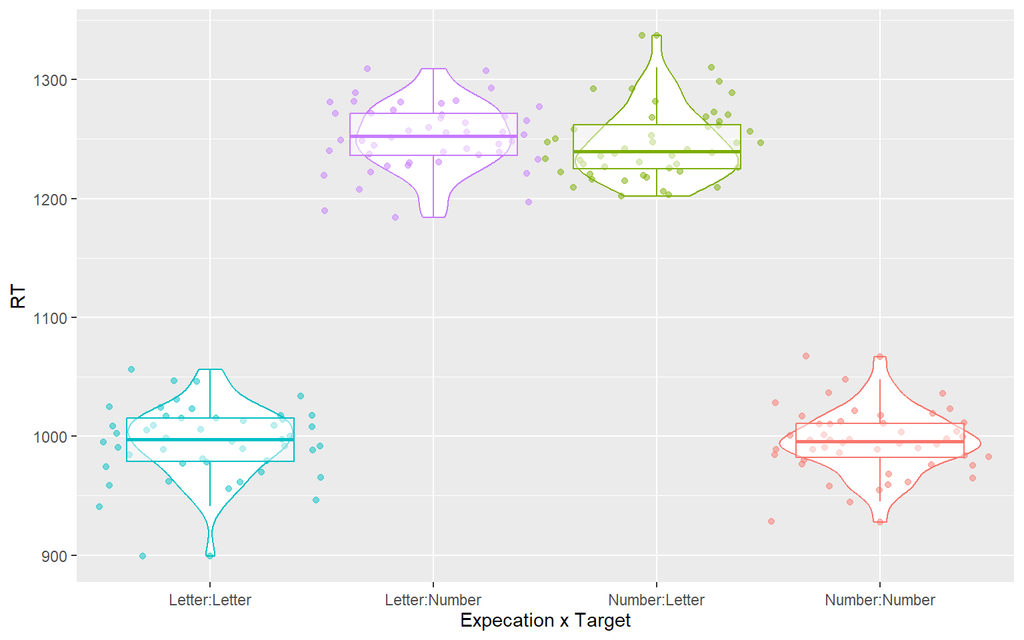

A Mixed Plot Which Provies More Information

```r
# The plot is developed with interaction effects(Expecation x Target)
ggplot(data = converted_data,
       mapping = aes(x = Expectation:Target,
                     y = RT,
                     colour = Conditions, )) +
  geom_violin() +
  geom_jitter(width = .5, alpha = .5) +
  geom_boxplot(alpha = .5) +
  guides(colour = "none") +
  theme(axis.text.x = element_text(angle = 0, vjust = 0.5, hjust = .5)) +
  labs(x = "Expecation x Target")
```

From the plot we can also discover the difference *when the expectation and target are consistent* and *when they are not*.

## Data Comparisons

From the plots above, we can learn that there may be a difference *when the expectation and target are consistent* and *when they are not*. But we still need to verify. Therefore, a bar chart is created, and the difference in mean value under two different circumstances is examined(in paired t-test).

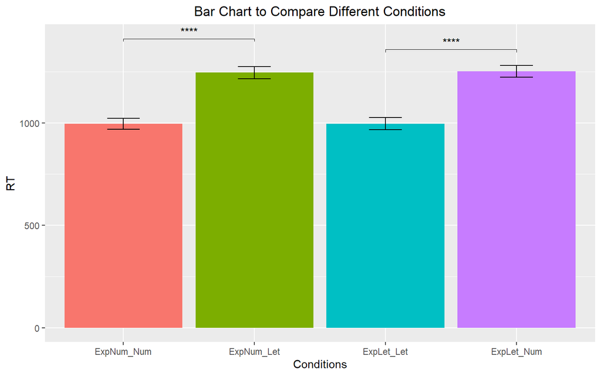

****p<0.0001

```r
# take a look at data in each condition.
ggplot(data = converted_data, aes(x = Conditions, y = RT, fill = Conditions)) +
  # use stat_summary to calculate mean and add a layer of error bar,which can be used by the next layer
  stat_summary(fun = "mean", geom = "bar") +
  stat_summary(
    fun.data = "mean_sd",
    geom = "errorbar",
    color = "black",
    width = .25,
    position = position_dodge(.9)
  ) +
  stat_compare_means(
    comparisons = list(c("ExpLet_Let", "ExpLet_Num"),
                       c("ExpNum_Num", "ExpNum_Let")),
    # use paired t-test here
    paired = TRUE,
    symnum.args = list(
      # use * to illustrate the p value
      cutpoints = c(0, 0.0001, 0.001, 0.01, 0.05, Inf),
      symbols = c("****", "***", "**", "*", "ns")
    )
  ) +
  labs(title = "Bar Chart to Compare Different Conditions") +
  theme(legend.position = "none", plot.title = element_text(hjust = 0.5))
```

The chart shows us that the difference between *when the expectation and target are consistent* and *when they are not* is significant(p<0.0001).

——The End——